# Easy_Visa

#### Based on the tuned XGBoost Classifier's performance on the unseen test set, the following observations can be made:

##### Accuracy: The model achieves an overall accuracy of approximately 71.31% on the test set, representing the proportion of total predictions — across both Certified and Denied cases — that were correctly classified.

##### Precision: The precision score of approximately 71.55% indicates that when the model predicts a visa application as Certified, it is correct roughly 71.55% of the time. Consequently, approximately 28.45% of applications predicted as Certified were actually Denied in the ground truth, reflecting a moderate rate of false positives. This suggests that the model leans toward approving applications rather than risking the misclassification of a genuinely qualified candidate.

##### Recall: The model records an exceptionally high recall score of approximately 94.71%, confirming that it correctly identifies nearly 95% of all truly Certified applications. This is the model's most notable strength — very few deserving applications are incorrectly flagged for denial, making the model highly reliable for minimizing missed certifications.

##### F1-Score: The F1-score of approximately 81.52% reflects a strong balance between precision and recall, and is notably higher than the overall accuracy of 71.31%. This divergence indicates that the model performs particularly well on the majority class (Certified) and that accuracy alone would underrepresent the model's true predictive capability in the presence of class imbalance.

##### Overall Inference: The tuned XGBoost Classifier demonstrates strong predictive performance on the test set, particularly in its ability to correctly identify the vast majority of Certified visa applications — a quality that makes it well-suited for deployment in scenarios where minimizing missed certifications is the primary objective. However, the gap between recall (94.71%) and precision (71.55%) highlights a precision-recall trade-off that warrants consideration. The relatively higher false positive rate means the model will occasionally certify applications that should have been denied, which may have operational implications depending on the cost associated with such errors. Should reducing false positives become a priority, further refinement through threshold adjustment, additional feature engineering, or alternative model configurations may be worth exploring.

## Important features of the final model

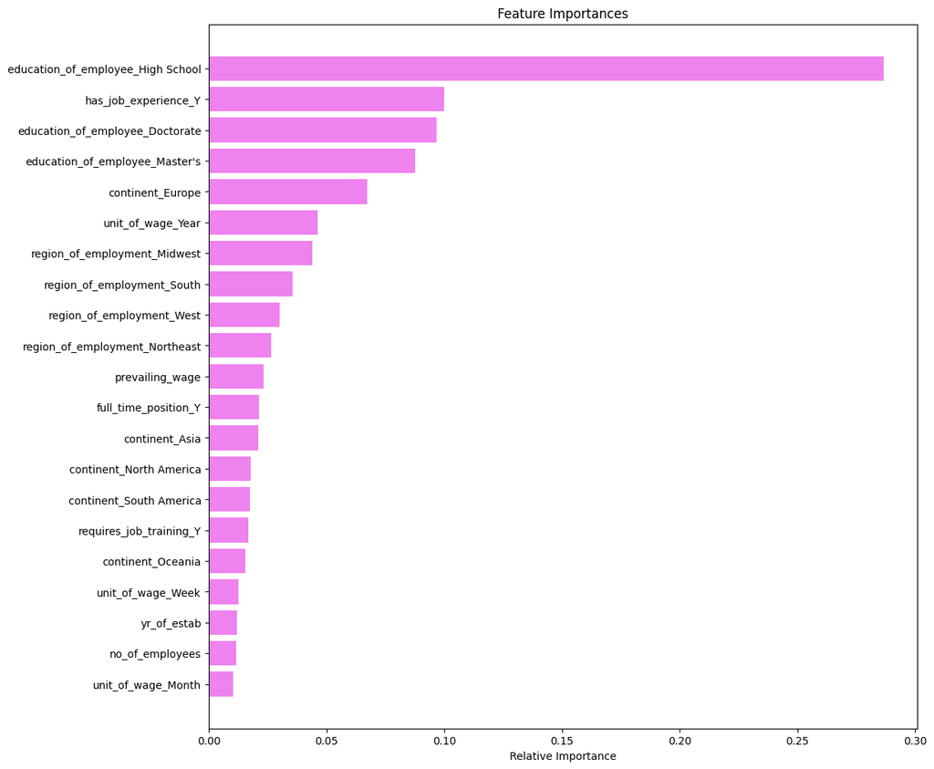

```python
feature_names = X_train.columns
# Complete the code to get the feature importances of the best model
importances = xgb_tuned.feature_importances_

indices = np.argsort(importances)
plt.figure(figsize=(12, 12))
plt.title("Feature Importances")
plt.barh(range(len(indices)), importances[indices], color="violet", align="center")
plt.yticks(range(len(indices)), [feature_names[i] for i in indices])
plt.xlabel("Relative Importance")
plt.show()
```

## Based on the data analysis, the performance of the Tuned XGBoost model, and the feature importance rankings, here are the , conclusions, actionable insights, and recommendations for EasyVisa and the Office of Foreign Labor Certification (OFLC).

### Actionable Insights

##### Manage the Precision-Recall Trade-off: The XGBoost model's higher recall relative to precision means it will rarely miss a genuinely Certified case, but will occasionally predict Certified for applications that should be Denied. Where the operational cost of false positives is high, further model refinement — such as threshold adjustment or the adoption of cost-sensitive learning — should be considered.

### Recommendations

##### Data Validation for Prevailing Wage: Investigate the extremely low prevailing_wage values identified during preprocessing and implement data validation rules at the point of entry to prevent such anomalies from propagating into future model training cycles, as they could compromise prediction reliability.

##### Strategic Application Guidance: Advise applicants to clearly highlight higher educational qualifications and relevant job experience in their applications. For sponsoring employers, offering annual wage structures where feasible — rather than hourly arrangements — is recommended to improve certification prospects.

#### Implement a Tiered Review System (OFLC): A risk-based, tiered approach to application review could significantly improve processing efficiency:

##### Tier 1 — Expedited Approval: Applications meeting strong certification criteria (Master's degree or higher, high prevailing wage, established employer, prior experience) may be candidates for streamlined or automated certification, potentially reducing manual review workload considerably.

##### Tier 2 — Priority Review: Applications where the model predicts Certified but with a borderline confidence score (e.g., between 0.50 and 0.70) should be flagged for closer human review.

##### Tier 3 — Mandatory Audit: All applications predicted as Denied, as well as those involving recently established companies or applicants with only a High School education, should be subject to mandatory manual audit.

##### Threshold Tuning for Precision Improvement: Rather than relying on the default classification threshold of 0.50, adjusting the threshold upward (e.g., to 0.65–0.70) would increase precision — ensuring that when the model predicts Certified, it does so with greater confidence — at the cost of a modest reduction in recall. This adjustment may be appropriate in contexts where the cost of false positives is elevated.

##### Address Class Imbalance with Cost-Sensitive Learning: Given the model's current tendency toward false positives, implementing cost-sensitive learning — which penalizes the model more heavily for incorrectly predicting Denied cases as Certified — could improve the balance between precision and recall without sacrificing the volume of training data.

##### Incorporate Occupation-Specific Data: The current model relies on broad regional and categorical features. Incorporating Standard Occupational Classification (SOC) codes into future iterations would provide a more granular basis for wage competitiveness assessments and could meaningfully improve the model's ability to evaluate whether a given wage is truly aligned with the role and region in question.

##### Continuous Monitoring and Retraining: Model performance should be monitored regularly on incoming data, and the model should be retrained periodically to account for evolving visa policies, labor market dynamics, and shifts in feature importance over time.

##### Explore Explainable AI (XAI) Techniques: Given the high-stakes nature of visa certification decisions, the adoption of explainability tools such as SHAP (SHapley Additive exPlanations) values is strongly recommended. These techniques would enable granular, case-level explanations for individual predictions — going beyond aggregate feature importance to clarify why a specific application was predicted as Certified or Denied — thereby improving transparency and supporting human oversight of model decisions.